# TAREA DE OBESIDAD

## **Choque Cachi Vismark Abner** 2025-03-30

# LECTURA DE DATOS

```r
library(readxl)
datos <- read.csv("C:/Users/Vismark Choque/Downloads/obe.csv", header = TRUE, sep = ",")
```

**VISUALIZACION DE LOS DATOS**

```r
datos
```

| Sexo | Edad | Altura | Peso | FamiliarPeso | AVCBi | FCVCNu | NCPNu | CAEC | Fuma | CH2O | SCC | FAF | TUE | CALC | MTRANS | NObeyesdad |
| --- | --- | --- | --- | --- | --- | --- | --- | --- | --- | --- | --- | --- | --- | --- | --- | --- |
| Female | 21.00000 | 1.620000 | 64.00000 | yes | no | 2.000000 | 3.000000 | Sometimes | no | 2.000000 | no | 0.000000 | 1.000000 | no | Public_Transportation | Normal_Weight |
| Female | 21.00000 | 1.520000 | 56.00000 | yes | no | 3.000000 | 3.000000 | Sometimes | yes | 3.000000 | yes | 3.000000 | 0.000000 | Sometimes | Public_Transportation | Normal_Weight |
| Male | 23.00000 | 1.800000 | 77.00000 | yes | no | 2.000000 | 3.000000 | Sometimes | no | 2.000000 | no | 2.000000 | 1.000000 | Frequently | Public_Transportation | Normal_Weight |
| Male | 27.00000 | 1.800000 | 87.00000 | no | no | 3.000000 | 3.000000 | Sometimes | no | 2.000000 | no | 2.000000 | 0.000000 | Frequently | Walking | Overweight_Level_I |
| Male | 22.00000 | 1.780000 | 89.80000 | no | no | 2.000000 | 1.000000 | Sometimes | no | 2.000000 | no | 0.000000 | 0.000000 | Sometimes | Public_Transportation | Overweight_Level_II |
| Male | 29.00000 | 1.620000 | 53.00000 | no | yes | 2.000000 | 3.000000 | Sometimes | no | 2.000000 | no | 0.000000 | 0.000000 | Sometimes | Automobile | Normal_Weight |
| Female | 23.00000 | 1.500000 | 55.00000 | yes | yes | 3.000000 | 3.000000 | Sometimes | no | 2.000000 | no | 1.000000 | 0.000000 | Sometimes | Motorbike | Normal_Weight |
| Male | 22.00000 | 1.640000 | 53.00000 | no | no | 2.000000 | 3.000000 | Sometimes | no | 2.000000 | no | 3.000000 | 0.000000 | Sometimes | Public_Transportation | Normal_Weight |
| Male | 24.00000 | 1.780000 | 64.00000 | yes | yes | 3.000000 | 3.000000 | Sometimes | no | 2.000000 | no | 1.000000 | 1.000000 | Frequently | Public_Transportation | Normal_Weight |
| Male | 22.00000 | 1.720000 | 68.00000 | yes | yes | 2.000000 | 3.000000 | Sometimes | no | 2.000000 | no | 1.000000 | 1.000000 | no | Public_Transportation | Normal_Weight |

[output cut: 990 more lines]

# VERIFICACION DATOS FALTANTES

```r
library(dplyr)

# Ver datos faltantes por columna
datos_faltantes<- colSums(is.na(datos))  # Suma de NA por columna
print(datos_faltantes)
```

```
##         Sexo         Edad       Altura         Peso FamiliarPeso        AVCBi       FCVCNu        NCPNu         CAEC         Fuma
##            0            0            0            0            0            0            0            0            0            0
##         CH2O          SCC          FAF          TUE         CALC       MTRANS   NObeyesdad
##            0            0            0            0            0            0            0
```

```r
# Instalar librerias
if (!require(visdat)) {
  install.packages("visdat")
}
```

VISUALIZACION DE DATOS FALTANTES

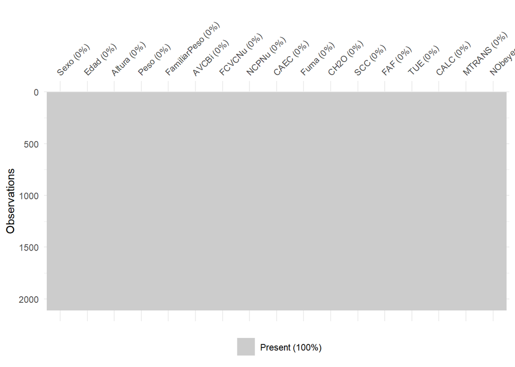

```r
# Importar librerias
library(visdat)
# Graficar
# Ver datos faltantes por columna
vis_miss(datos ,sort_miss = TRUE)
```

# DISTRIBUCION DE LOS DATOS

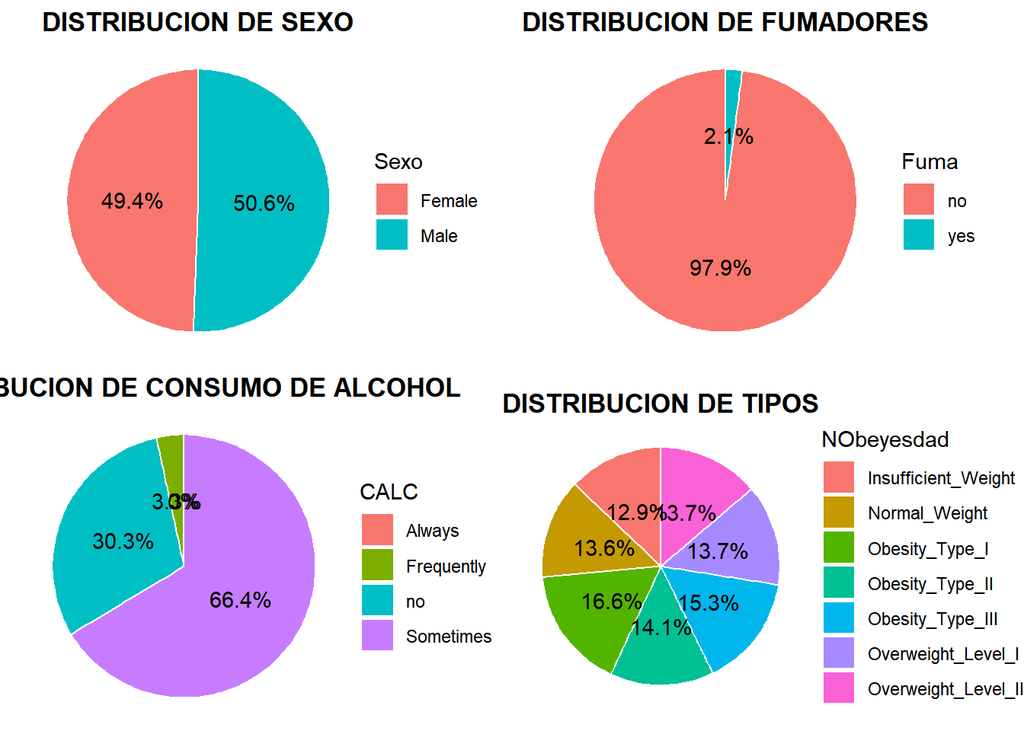

```r
# Cargar librerías
library(ggplot2)
library(gridExtra)

# Lista de columnas y títulos
columnas <- c("Sexo", "Fuma", "CALC", "NObeyesdad")
titulos <- c("DISTRIBUCION DE SEXO", "DISTRIBUCION DE FUMADORES",
             "DISTRIBUCION DE CONSUMO DE ALCOHOL", "DISTRIBUCION DE TIPOS")

# Crear gráficos con lapply
graficos <- lapply(1:length(columnas), function(i) {
  ggplot(as.data.frame(table(datos[[columnas[i]]])), aes(x = "", y = Freq, fill = Var1)) +
    geom_bar(stat = "identity", width = 1, color = "white") +
    coord_polar(theta = "y") +
    labs(title = titulos[i], x = NULL, y = NULL, fill = columnas[i]) +
    geom_text(aes(label = paste0(round(Freq / sum(Freq) * 100, 1), "%")),
              position = position_stack(vjust = 0.5), color = "black") +
    theme_void() +
    theme(legend.position = "right", plot.title = element_text(hjust = 0.5, face = "bold"))
})

# Unir los gráficos en una sola figura
grid.arrange(grobs = graficos, ncol = 2)
```

### DISTRIBUCIONES

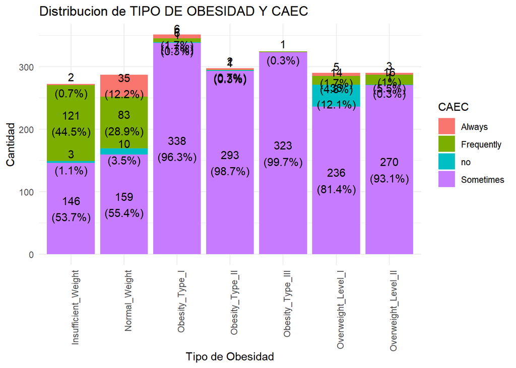

```r
# Cargar las librerías necesarias
library(ggplot2)
library(dplyr)

# Función para generar el gráfico de barras apiladas con valores y porcentajes
grafico_obesidad_caec <- function(datos, columna_tipo_obesidad, columna_caec, titulo) {
  # Resumen de los datos: Contar la cantidad de ocurrencias para cada combinación de tipo de obesidad y CAEC
  df_summary <- datos %>%
    group_by(.data[[columna_tipo_obesidad]], .data[[columna_caec]]) %>%
    summarise(Total_Clientes = n()) %>%
    mutate(Porcentaje = Total_Clientes / sum(Total_Clientes) * 100)

  # Gráfico de barras apiladas con valor y porcentaje
  ggplot(df_summary, aes(x = .data[[columna_tipo_obesidad]], y = Total_Clientes, fill = .data[[columna_caec]])) +
    geom_bar(stat = "identity", position = "stack") +
    geom_text(aes(label = paste0(Total_Clientes, "\n(", round(Porcentaje, 1), "%)")),
              position = position_stack(vjust = 0.5), color = "black") +
    labs(title = titulo, x = "Tipo de Obesidad", y = "Cantidad") +
    theme_minimal() +
    theme(axis.text.x = element_text(angle = 90, hjust = 1))
}

grafico_obesidad_caec(datos, columna_tipo_obesidad = "NObeyesdad", columna_caec = "CAEC",titulo = "Distribucion de TIPO DE OBESIDAD Y CAEC" )
```

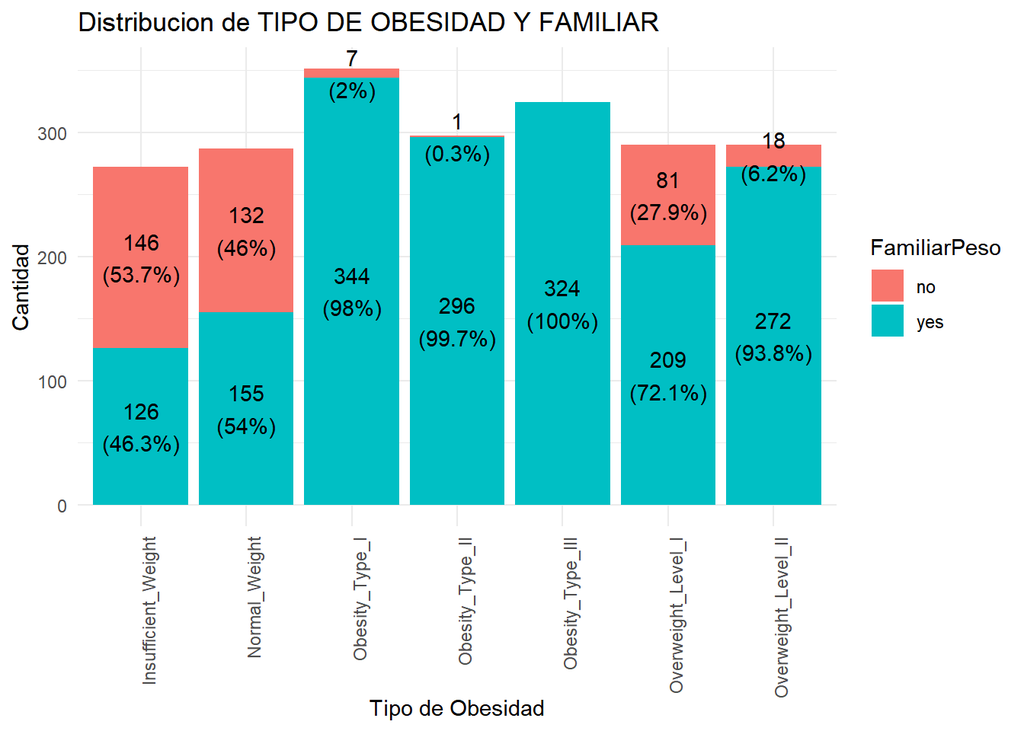

```r
grafico_obesidad_caec(datos, columna_tipo_obesidad = "NObeyesdad", columna_caec = "FamiliarPeso",titulo = "Distribucion de TIPO DE OBESIDAD Y FAMILIAR" )
```

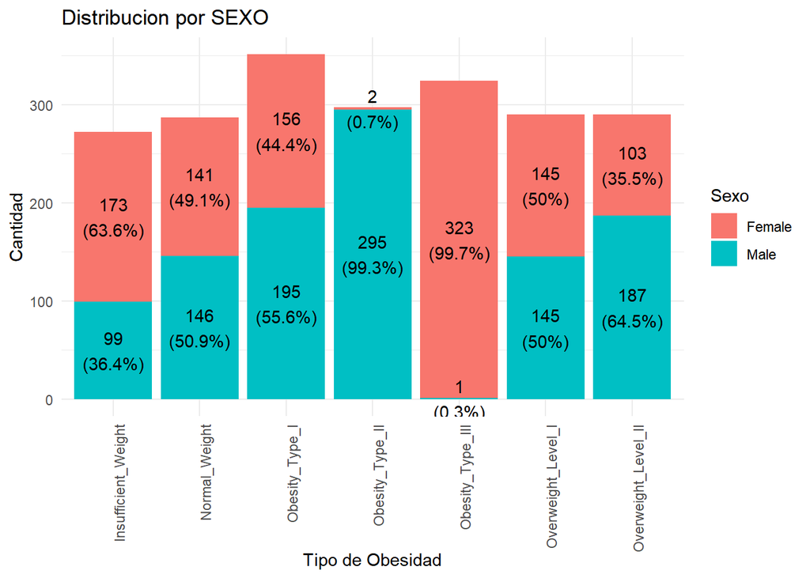

```r
grafico_obesidad_caec(datos, columna_tipo_obesidad = "NObeyesdad", columna_caec = "Sexo",titulo = "Distribucion por SEXO")
```

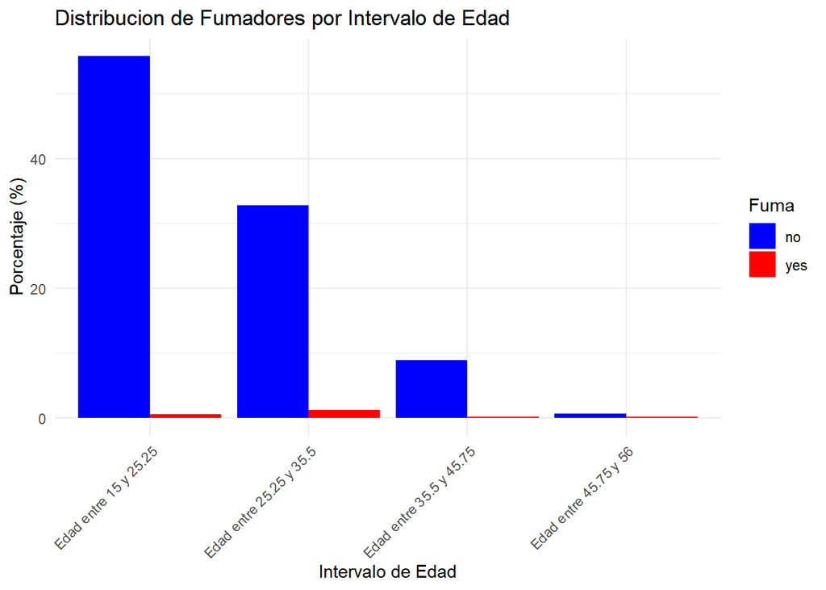

```r
# Cargar librerías necesarias
library(ggplot2)
library(dplyr)

# Filtrar los datos para excluir "Insufficient_Weight" y "Normal_Weight"
datos_filtrados <- datos %>%
  filter(!NObeyesdad %in% c("Insufficient_Weight", "Normal_Weight"))

# Definir el número de intervalos de edad
x <- 4
rango <- max(datos_filtrados$Edad) - min(datos_filtrados$Edad)
anchura <- rango / x
bins <- seq(min(datos_filtrados$Edad), max(datos_filtrados$Edad), by = anchura)

# Crear los intervalos de edad con etiquetas
bin_labels <- cut(datos_filtrados$Edad, breaks = bins, include.lowest = TRUE)
labels <- paste("Edad entre", bins[-length(bins)], "y", bins[-1])
datos_filtrados$IntervaloEdad <- factor(bin_labels, labels = labels)

# Agrupar los datos por Intervalo de Edad y Fuma (sí/no)
datos_por_fuma <- datos_filtrados %>%
  group_by(IntervaloEdad, Fuma) %>%
  summarise(Conteo = n(), .groups = "drop") %>%
  mutate(Porcentaje = Conteo / sum(Conteo) * 100)

# Crear gráfico de barras para "Fuma"
ggplot(datos_por_fuma, aes(x = IntervaloEdad, y = Porcentaje, fill = Fuma)) +
  geom_bar(stat = "identity", position = "dodge") +  # Gráfico de barras agrupadas
  labs(title = "Distribucion de Fumadores por Intervalo de Edad",
       x = "Intervalo de Edad",
       y = "Porcentaje (%)",
       fill = "Fuma") +
  theme_minimal() +
  theme(axis.text.x = element_text(angle = 45, hjust = 1)) +  # Rotar etiquetas del eje X
  scale_fill_manual(values = c("yes" = "red", "no" = "blue"))  # Colores para "sí" y "no"
```

## MAPA DE CALOR

**Filtrar variables categoricas y numericas**

```r
# Filtrar las variables categóricas y numéricas
var_categoricas <- names(datos)[sapply(datos, is.character)]
var_numericas <- names(datos)[sapply(datos, is.numeric)]
```

### Mapa de Calor para las Variables Categóricas

En esta sección, se calcula el coeficiente de contingencia para las variables categóricas y se genera un mapa de calor para visualizar las asociaciones entre ellas.

**Función para Calcular el Coeficiente de Contingencia** El coeficiente de contingencia se calcula a partir de la prueba de Chi-cuadrado y mide la fuerza de la asociación entre dos variables categóricas.

```r
# Función para calcular el coeficiente de contingencia
ContCoef <- function(x) {
  chi2 <- chisq.test(x)
  return(sqrt(chi2$statistic / (chi2$statistic + sum(x))))
}
```

**Calcular el Coeficiente de Contingencia** Se calculan los coeficientes de contingencia para cada par de variables categóricas y se almacenan en una matriz.

```r
# Crear una matriz vacía para almacenar los coeficientes de contingencia
contingency_matrix_cat <- matrix(NA, nrow = length(var_categoricas),
                                 ncol = length(var_categoricas),
                                 dimnames = list(var_categoricas, var_categoricas))

# Calcular coeficiente de contingencia para las variables categóricas
for (i in 1:length(var_categoricas)) {
  for (j in i:length(var_categoricas)) {  # Incluye la diagonal
    tabla <- table(datos[[var_categoricas[i]]], datos[[var_categoricas[j]]])
    contingency_matrix_cat[i, j] <- ContCoef(tabla)  # Calcula coeficiente de contingencia
    contingency_matrix_cat[j, i] <- contingency_matrix_cat[i, j]  # Mantener simetría
  }
}
```

**Crear el Mapa de Calor** Convertimos la matriz de coeficientes en un DataFrame para poder visualizarlo con ggplot2.

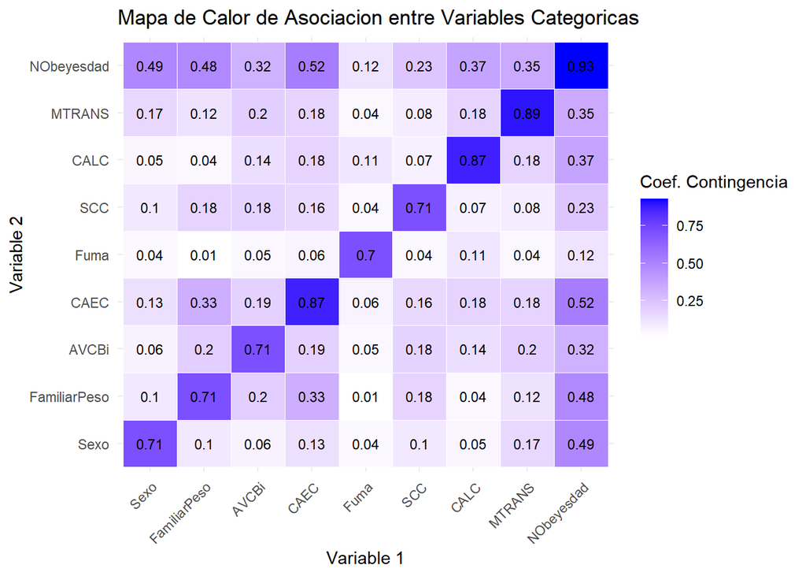

```r
# Convertir la matriz en un DataFrame para ggplot2
library(reshape2)
contingency_df_cat <- melt(contingency_matrix_cat, na.rm = TRUE)

# Crear el mapa de calor para las variables categóricas
library(ggplot2)
ggplot(contingency_df_cat, aes(Var1, Var2, fill = value)) +
  geom_tile(color = "white") +  # Color blanco en las celdas
  geom_text(aes(label = round(value, 2)), color = "black", size = 3) +  # Mostrar valores numéricos
  scale_fill_gradient(low = "white", high = "blue", name = "Coef. Contingencia") +
  theme_minimal() +
  labs(title = "Mapa de Calor de Asociacion entre Variables Categoricas",
       x = "Variable 1",
       y = "Variable 2") +
  theme(axis.text.x = element_text(angle = 45, hjust = 1))  # Rotar etiquetas en el eje X
```

### Mapa de Calor para las Variables Numéricas

En esta sección, se calcula la correlación de Pearson para las variables numéricas y se genera un mapa de calor para visualizar la relación entre ellas.

**Calcular las Correlaciones de Pearson** Para las variables numéricas, calculamos la correlación de Pearson, que mide la relación lineal entre dos variables numéricas.

```r
# Crear una matriz vacía para almacenar las correlaciones de Pearson
contingency_matrix_num <- matrix(NA, nrow = length(var_numericas),
                                 ncol = length(var_numericas),
                                 dimnames = list(var_numericas, var_numericas))

# Calcular las correlaciones de Pearson para las variables numéricas
for (i in 1:length(var_numericas)) {
  for (j in i:length(var_numericas)) {  # Incluye la diagonal
    corr <- cor(datos[[var_numericas[i]]], datos[[var_numericas[j]]], use = "complete.obs")
    contingency_matrix_num[i, j] <- corr  # Almacenar la correlación
    contingency_matrix_num[j, i] <- contingency_matrix_num[i, j]  # Mantener simetría
  }
}
```

** Crear el Mapa de Calor para Variables Numéricas** Al igual que con las variables categóricas, convertimos la matriz de correlaciones en un DataFrame para visualizarla con ggplot2.

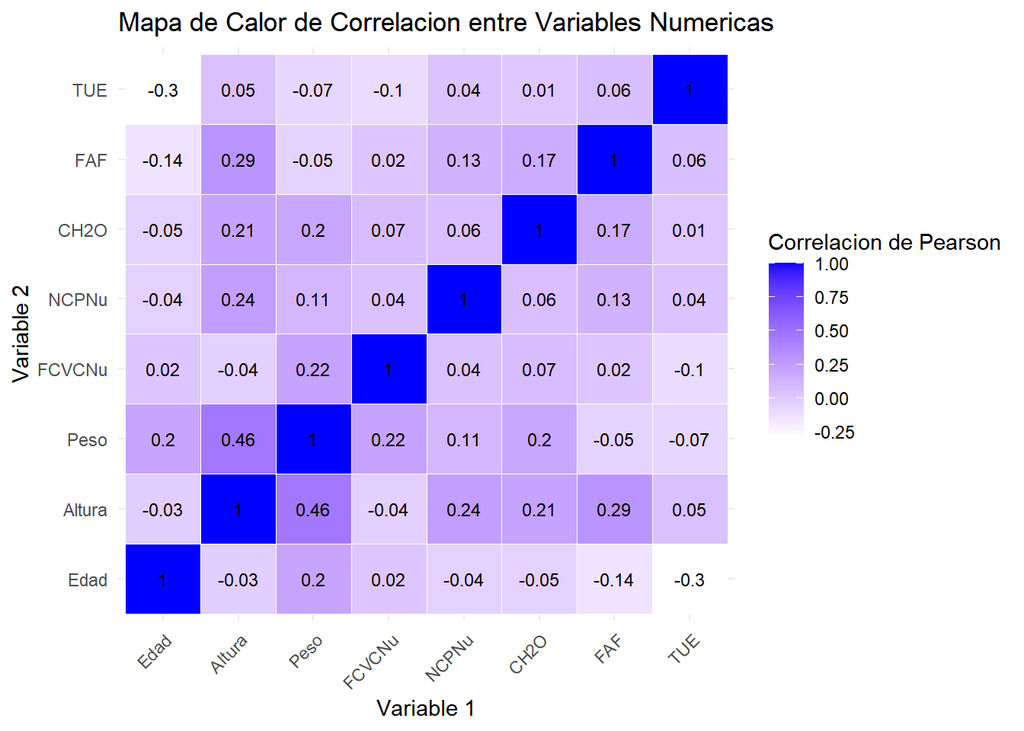

```r
# Convertir la matriz en un DataFrame para ggplot2
contingency_df_num <- melt(contingency_matrix_num, na.rm = TRUE)

# Crear el mapa de calor para las variables numéricas
ggplot(contingency_df_num, aes(Var1, Var2, fill = value)) +
  geom_tile(color = "white") +  # Color blanco en las celdas
  geom_text(aes(label = round(value, 2)), color = "black", size = 3) +  # Mostrar valores numéricos
  scale_fill_gradient(low = "white", high = "blue", name = "Correlacion de Pearson") +
  theme_minimal() +
  labs(title = "Mapa de Calor de Correlacion entre Variables Numericas",
       x = "Variable 1",
       y = "Variable 2") +
  theme(axis.text.x = element_text(angle = 45, hjust = 1))  # Rotar etiquetas en el eje X
```

** Instalar librerias **

```r
if (!require(randomForest)){
  install.packages("randomForest")
}
```

```r
# Cargar las librerías
library(randomForest)
library(dplyr)
```

Dividir los datos en conjunto de entrenamiento y prueba

```r
datos$NObeyesdad <- as.factor(datos$NObeyesdad)

# Dividir los datos en entrenamiento (80%) y prueba (20%)
set.seed(123)
train_indices <- sample(1:nrow(datos), 0.8 * nrow(datos))
train_data <- datos[train_indices, ]
test_data <- datos[-train_indices, ]

# Entrenar el modelo de Random Forest con OOB activado
modelo_rf_ajustado <- randomForest(
  NObeyesdad ~ .,
  data = train_data,
  ntree = 100,
  mtry = 6,
  importance = TRUE,
  keep.forest = TRUE,
  oob.prox = TRUE
)

# Ver el modelo
print(modelo_rf_ajustado)
```

```
##
## Call:
##  randomForest(formula = NObeyesdad ~ ., data = train_data, ntree = 100,      mtry = 6, importance = TRUE, keep.forest = TRUE, oob.prox = TRUE)
##                Type of random forest: classification
##                      Number of trees: 100
## No. of variables tried at each split: 6
##
##         OOB estimate of  error rate: 5.04%
## Confusion matrix:
##                     Insufficient_Weight Normal_Weight Obesity_Type_I Obesity_Type_II Obesity_Type_III Overweight_Level_I
## Insufficient_Weight                 219            10              0               0                0                  0
## Normal_Weight                         9           212              0               0                0                 11
## Obesity_Type_I                        0             2            267               2                0                  1
## Obesity_Type_II                       0             0              2             226                1                  0
## Obesity_Type_III                      0             0              0               0              264                  0
## Overweight_Level_I                    0            23              0               0                0                204
## Overweight_Level_II                   0             5              4               0                0                  5
##                     Overweight_Level_II class.error
## Insufficient_Weight                   0  0.04366812
## Normal_Weight                         0  0.08620690
## Obesity_Type_I                        4  0.03260870
## Obesity_Type_II                       0  0.01310044
## Obesity_Type_III                      0  0.00000000
## Overweight_Level_I                    6  0.12446352
## Overweight_Level_II                 211  0.06222222
```

```r
# 🔹 Exactitud con muestras "out-of-bag" (OOB)
oob_score <- 1 - modelo_rf_ajustado$err.rate[nrow(modelo_rf_ajustado$err.rate), "OOB"]
cat(sprintf("Exactitud validacion (OOB): %.1f%%\n", 100 * oob_score))
```

```
## Exactitud validacion (OOB): 95.0%
```

```r
# 🔹 Desempeño con el conjunto de prueba
predicciones <- predict(modelo_rf_ajustado, test_data)
accuracy_test <- mean(predicciones == test_data$NObeyesdad)
cat(sprintf("Exactitud prueba: %.1f%%\n", 100 * accuracy_test))
```

```
## Exactitud prueba: 96.2%
```

```r
# 🔹 Predecir para un cliente específico (ejemplo: fila 22 del conjunto de prueba)
cliente <- test_data[22, -which(names(test_data) == "NObeyesdad")]
print("Caracteristicas")
```

```
## [1] "Caracteristicas"
```

```r
print(cliente)
```

```
##       Sexo Edad Altura Peso FamiliarPeso AVCBi FCVCNu NCPNu      CAEC Fuma CH2O SCC FAF TUE CALC                MTRANS
## 110 Female   21   1.65   88          yes   yes      3     1 Sometimes   no    3  no   2   1   no Public_Transportation
```

```r
prediccion <- predict(modelo_rf_ajustado, cliente)
cat(rep("-", 100), "\n")
cat(sprintf("Prediccion %s\n", prediccion))
```

[output not shown]